# In the name of God

## AI CA3-Naive Bayes Classifier

## Name: Marzieh Bagherinia Amiri

## Student Id: 810197682

#### Spring 1400

## ● هدف پروژه

هدف از انجام این پروژه پیش بینی دسته‌بندی هر کتاب با توجه به کلمات متن یا موضوع آن است.

## ● دیتاهای پروژه

در این پروژه یک فایل با نام books_train.csv داده شده، که در واقع داده ما برای train شدن است و یک فایل با نام books_test.csv قرار دارد که در واقع برای راستی‌آزمایی الگوریتمی که نوشتیم، قرار داده شده است.

## ● نکته

پاسخ تمامی سوالات، در انتهای پروژه قرار گرفته است.

```python
import math
import numpy as np
import pandas as pd
import matplotlib.pyplot as plt
from hazm import *
```

```python
train_df = pd.read_csv('books_train.csv')
test_df = pd.read_csv('books_test.csv')
```

```python
stemmer = Stemmer()
normalizer = Normalizer()
lemmatizer = Lemmatizer()

whiteSpace = [':','؟','.',',','«','»','(',')','،','[',']','{','}','-','','؛', '#', '\r', '\n']
stopWord = [sw for sw in stopwords_list()]
stopWord.extend(whiteSpace)
categories = {0:'جامعه‌شناسی',
              1: 'داستان کوتاه',
              2:'داستان کودک و نوجوانان',
              3:'کلیات اسلام',
              4:'رمان',
              5:'مدیریت و کسب و کار'}
```

```python
kid = {'description': dict(), 'title': dict(), 'total': 0}
short = {'description': dict(), 'title': dict(), 'total': 0}
novel = {'description': dict(), 'title': dict(), 'total': 0}
islamic = {'description': dict(), 'title': dict(), 'total': 0}
business = {'description': dict(), 'title': dict(), 'total': 0}
sociology = {'description': dict(), 'title': dict(), 'total': 0}

def normalize_data(column, df):

    for index, row in df.iterrows():
        bag = [word for word in word_tokenize(normalizer.normalize(row[column]))]
        bag = list(filter(lambda word: word not in stopWord, bag))
        bag = [lemmatizer.lemmatize(word) for word in bag]

        for word in bag:
            cat = row['categories']

            if (cat == categories[0]):
                if word not in sociology[column]:
                    sociology[column][word] = 0
                sociology[column][word] += 1
                sociology['total'] += 1

            if (cat == categories[1]):
                if word not in short[column]:
                    short[column][word] = 0
                short[column][word] += 1
                short['total'] += 1

            if (cat == categories[2]):
                if word not in kid[column]:
                    kid[column][word] = 0
                kid[column][word] += 1
                kid['total'] += 1

            if (cat == categories[3]):
                if word not in islamic[column]:
                    islamic[column][word] = 0
                islamic[column][word] += 1
                islamic['total'] += 1

            if (cat == categories[4]):
                if word not in novel[column]:
                    novel[column][word] = 0
                novel[column][word]+= 1
                novel['total'] += 1

            if (cat == categories[5]):
                if word not in business[column]:
                    business[column][word] = 0
                business[column][word] += 1
                business['total'] += 1
```

```python
normalize_data('description', train_df)
normalize_data('title', train_df)
```

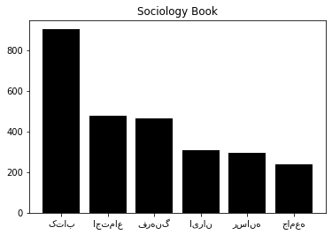

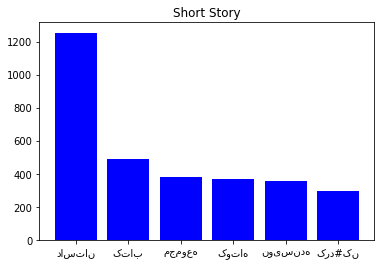

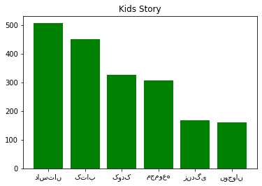

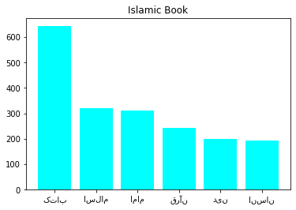

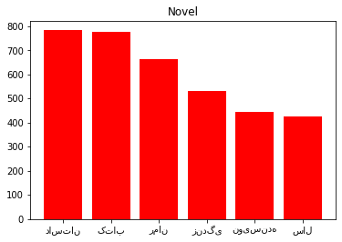

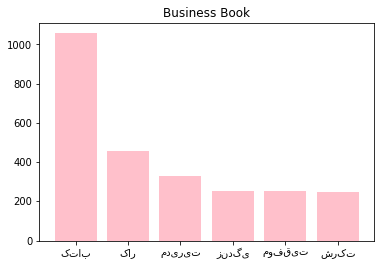

```python
def show_plot(category, title, col):
    res = dict(sorted(category['description'].items(), key = lambda x: x[1], reverse = True)[:6])
    plt.bar(res.keys(), res.values(), color = col)
    plt.title(title)
    plt.show()

show_plot(sociology, "Sociology Book", 'black')
show_plot(short, "Short Story", 'blue')
show_plot(kid, "Kids Story", 'green')
show_plot(islamic, "Islamic Book", 'cyan')
show_plot(novel, "Novel", 'red')
show_plot(business, "Business Book", 'pink')
```

```python
correct_detected_class = [0, 0, 0, 0, 0 , 0]
detected_class = [0, 0, 0, 0, 0 , 0]
total_class = [0, 0, 0, 0, 0 , 0]

incorrect_detected = []

def get_key(val):
    for key, value in categories.items():
         if val == value:
            return key

def find_category(df, smooth):
    smoothVal = [0, 0, 0, 0, 0, 0]
    if smooth != 0:
        smoothVal[0] = len(list(sociology['description'].keys()))
        smoothVal[1] = len(list(short['description'].keys()))
        smoothVal[2] = len(list(kid['description'].keys()))
        smoothVal[3] = len(list(islamic['description'].keys()))
        smoothVal[4] = len(list(novel['description'].keys()))
        smoothVal[5] = len(list(business['description'].keys()))

    for index, row in df.iterrows():
        bag = [word for word in word_tokenize(normalizer.normalize(row['description']))]
        bag = list(filter(lambda word: word not in stopWord, bag))
        bag = [lemmatizer.lemmatize(word) for word in bag]

        probs = [0, 0, 0, 0, 0, 0]

        len(list(sociology['description'].keys()))

        for word in bag:
            if word in sociology['description']:
                probs[0] += math.log(((sociology['description'][word] + smooth)/(sociology['total'] + smooth*smoothVal[0])),10)
            else:
                probs[0] += math.log(((pow(10,-8) + smooth)/(sociology['total'] + smooth*smoothVal[0])),10)

            if word in short['description']:
                probs[1] += math.log(((short['description'][word] + smooth)/(short['total'] + smooth*smoothVal[1])),10)
            else:
                probs[1] += math.log(((pow(10,-8) + smooth)/(short['total']+smooth*smoothVal[1])),10)

            if word in kid['description']:
                probs[2] += math.log(((kid['description'][word] + smooth)/(kid['total'] + smooth*smoothVal[2])),10)
            else:
                probs[2] += math.log(((pow(10,-8) + smooth)/(kid['total'] + smooth*smoothVal[2])),10)

            if word in islamic['description']:
                probs[3] += math.log(((islamic['description'][word] + smooth)/(islamic['total'] + smooth*smoothVal[3])),10)
            else:
                probs[3] += math.log(((pow(10,-8) + smooth)/(islamic['total'] + smooth*smoothVal[3])),10)

            if word in novel['description']:
                probs[4] += math.log(((novel['description'][word] + smooth)/(novel['total'] + smooth*smoothVal[4])),10)
            else:
                probs[4] += math.log(((pow(10,-8) + smooth)/(novel['total'] + smooth*smoothVal[4])),10)

            if word in business['description']:
                probs[5] += math.log(((business['description'][word] + smooth)/(business['total'] + smooth*smoothVal[5])),10)
            else:
                probs[5] += math.log(((pow(10,-8) + smooth)/(business['total'] + smooth*smoothVal[5])),10)

        detected_class[probs.index(max(probs))] += 1
        total_class[get_key(row['categories'])] += 1

        if (row['categories'] == categories[probs.index(max(probs))]):
            correct_detected_class[probs.index(max(probs))] += 1
        else:
            incorrect_detected.append(row['title'])
```

```python
def evaluation():
    for i in range (6):
        print("Category ", categories[i], ":")
        precision = correct_detected_class[i]/detected_class[i]
        recall = correct_detected_class[i]/total_class[i]
        f1 = 2*precision*recall/(precision + recall)
        print("Precision: ", precision)
        print("Recall: ", recall)
        print("F1: ", f1)
        print()

    print()
    print("Accuracy: ", sum(correct_detected_class)/sum(total_class))
```

```python
find_category(test_df, 0)
evaluation()
```

```
Category  جامعه‌شناسی :
Precision:  0.7127659574468085
Recall:  0.8933333333333333
F1:  0.7928994082840236

Category  داستان کوتاه :
Precision:  0.546875
Recall:  0.4666666666666667
F1:  0.5035971223021581

Category  داستان کودک و نوجوانان :
Precision:  0.9230769230769231
Recall:  0.64
F1:  0.7559055118110237

Category  کلیات اسلام :
Precision:  0.9666666666666667
Recall:  0.7733333333333333
F1:  0.8592592592592593

Category  رمان :
Precision:  0.5398230088495575
Recall:  0.8133333333333334
F1:  0.648936170212766

Category  مدیریت و کسب و کار :
Precision:  0.9552238805970149
Recall:  0.8533333333333334
F1:  0.9014084507042254


Accuracy:  0.74
```

```python
find_category(test_df, 1)
evaluation()
```

```
Category  جامعه‌شناسی :
Precision:  0.7542857142857143
Recall:  0.88
F1:  0.8123076923076923

Category  داستان کوتاه :
Precision:  0.6475409836065574
Recall:  0.5266666666666666
F1:  0.5808823529411764

Category  داستان کودک و نوجوانان :
Precision:  0.6982248520710059
Recall:  0.7866666666666666
F1:  0.7398119122257053

Category  کلیات اسلام :
Precision:  0.9375
Recall:  0.8
F1:  0.8633093525179856

Category  رمان :
Precision:  0.6296296296296297
Recall:  0.68
F1:  0.6538461538461539

Category  مدیریت و کسب و کار :
Precision:  0.9305555555555556
Recall:  0.8933333333333333
F1:  0.9115646258503401


Accuracy:  0.7611111111111111
```

```python
print("Five false predictions: ")
for i in range(5):
    print(i + 1, incorrect_detected[i])
```

```
Five false predictions:
1 کآشوب
2 اسلام و چالش اقتصادی
3 دری در دیوار
4 مطلقاً تقریباً
5 موش و گربه
```

## ○ سوال شماره یک

تفاوت Stemming و Lemmatization:  
در استیمینگ قسمت‌های اضافی ابتدا و انتهای کلمه، مثل ها، ام، اید و ... حذف می‌شوند اما اما در لمیتیزشن، کلمه به فرم ریشه‌ی واقعی‌اش در می‌آید. مثلا می‌روم تبدیل به رو می‌شود.

## ○ Effect on Accuracy

|  | Without Smoothing | With Smoothing |
| --- | --- | --- |
| Stemming | 0.72 | 0.75 |
| Lemmatization | 0.74 | 0.7611111111111111 |
| Both | 0.7088888888888889 | 0.7455555555555555 |
| None | 0.7311111111111112 | 0.7188888888888889 |

## ○ سوال شماره دو

احتمال با فرض اینکه کتاب به دسته‌ای تعلق دارد یا خیر بررسی می‌شود:  
class prior probability : احتمال این که یک کتاب به یک دسته‌ی خاص تعلق داشه باشد بدون داشتن هیچ اطلاعات اضافی دیگری.  
Posterior probability: احتمال این که یک کتاب به یک دسته‌ی خاص تعلق داشه باشد با فرض اینکه یک کلمه خاص دیده شود.  
likelihood: احتمال وجود یک لغت در شرایطی که بدانیم کتاب از کدام کتگوری است.  
𝑥: احتمال دیدن یک کلمه!  
c: احتمال تعلق به یک کتگوری

## ○ سوال شماره سه

جمله اول: سیر میوه بسیار مقیدی برای تقویت سیستم ایمنی بدن است.  
جمله دوم: کودکان خیلی زود از غذا خوردن سیر می‌شوند.  
کلمه مشترک «سیر» است که در دو معنای متفاوت به کار رفته است.  
برای مثال بررسی Biagram به صورت میوه سیر، باعث می‌شود تا آن را با قطعیت از Biagram به صورت کودک سیر جدا کنیم؛ گاهی لازم است از n-gram هم استفاده کنیم و این زمانی است که تعداد n تا کلمه لازم باشد تا معنی و ددسته بندی عبارت مشخص شود.

## ○ سوال شماره چهار

در صورتی که یک کلمه فقط در یک نوع کتگوری موجود باشد، الگوریتم ، Naive Bayes قطعاً آن کتگوری را به عنوان پاسخ انتخاب می کند که لزوما انتخاب درستی نمی‌باشد. علت هم این است که در این صورت، p(x|c) = 0 خواهد بود و چون از log استفاده می‌کنیم، log(0) = -inf که این باعث می‌شود تاثیر سایر کلمات متن از بین رود و در نهایت احتمال تعلق به آن کتگوری که برابر با مجموع احتمال p(xi|c)هاست، -inf شود و این کتگوری هیچگاه انتخاب نشود که خب لزوما تصمیم‌گیری درستی نیست.

## ○ سوال شماره شش

قبل‌تر نمودارهای درخواستی این سوال رسم شده است.

## ○ سوال شماره هشت

در این میانگین نتیجه بیشتر به عدد کمتر (میان precision و recall) نزدیک است؛ اهمیت این میانگین این است که در آن هر دو عدد تاثیرگذار هستند و نمی‌توان با زیاد کردن دیگری میانگین را بالا برد پس از انتخاب تریدآف خیلی بد جلوگیری می‌کند و لازم است که دو عدد با هم متناسب باشند.

## ○ سوال شماره نه

Micro: میانگین معمولی بین تمامی f1 هاست.  
Macro: همان مقدار Accuracy است.  
Weighted: به هر اف۱ یکبا توجه به تعداد سمپل‌هایی که از یک کلاس موجود است، به هر f1 یک ورن می‌دهد و با توجه به آن وزن‌ها از داده‌ها میانگین وزن‌دار می‌گیرد.

## ○ سوال شماره ده

قبل‌تر انجام شد.

## ○ سوال شماره یازده

زمانی که از Smoothing استفاده می‌کنیم، نتیجه بهتری می‌گیریم چرا که از گرفتن تصمیم قطعی برای کلماتی که در یک کتگوری نیامده‌اند جلگوری می‌کنیم و همین شانس (حتی کوچکی) که برای آنها قرار می‌دهیم در نتیجه تاثیر گذاشته است؛ نکته‌ی مهم دیگر تفاوت پرسیشن و ریکال در نبودن Smoothing است. که دور از ذهن هم نبود با توجه به تاثیری که استفاده از Smoothing دارد و در بالا آن را توضیح دادیم.

## ○ سوال شماره دوازده

5 مورد از این پیش‌بینی‌های اشتباه در بالا آمده است.  
راهکار‌های بهتر شدن اگوریتم:  
دلیل اشتباه در این تست‌ها به نظر می‌تواند مشکل در تعداد کم بودن داده‌های آموزش باشد یا می‌تواند بد بودن پیش‌پردازشمان باشد که کلمات پر تکراری که در اکثر دسته‌ها بودند را حذف نکردیم یا از توابع lemmatization استفاده کردیم که به خوبی ریشه کلمات را نیافته است.